# Project: Investigate a Dataset - Gapminder World

- Introduction
- Data Wrangling
- Exploratory Data Analysis
- Conclusions

## Introduction

### Dataset Description

*FREE DATA FROM WORLD BANK VIA GAPMINDER.ORG, CC-BY LICENSE*

Gapminder has collected a lot of information about how people live their lives in different countries, tracked across the years, and on a number of different indicators.

#### Indicators choosen for this invistigation

##### 1- Children per woman (total fertility rare)

- Description: Total fertility rate. The number of children that would be born to each woman with precailing age-specific fertility rates.
- Source url: https://www.gapminder.org/data/documentation/gd008/
- csv file downloaded from: gapminder.org/data/ .. Choose individual indicators .. Babies per woman
- file name: children_per_woman_total_fertility.csv
- Dataset alias: df_tfr
- Dataset shape: 202 rows (countries) 302 columns (years from 1800 to 2100)

##### 2- Child Mortality Rate

- Description: Death of children under five years of age per 1,000 live births.
- Source url: https://www.gapminder.org/data/documentation/gd005/
- csv file downloaded from: gapminder.org/data/ .. Choose individual indicators .. Child mortality.
- file name: child_mortality_0_5_year_olds_dying_per_1000_born.csv
- Dataset alias: df_cmr
- Dataset shape: 197 rows (countries) 302 columns (years from 1800 to 2100)

##### 3- Employment rate % (females aged 15+)

- Description: Percentage of female population, age group 15+, that has been employed during the given year.
- Source url: https://ilostat.ilo.org/
- csv file downloaded from: gapminder.org/data/ .. Choose individual indicators .. Work .. Employment rate .. Female aged 15+
- file name: females_aged_15plus_employment_rate_percent.csv
- Dataset alias: df_erg
- Dataset shape: 189 rows (countries) 30 columns (years from 1991 to 2019)

### Questions for Analyses:

- Research Question 1 (What is the distribution of Total Fertility Rate over the years)
- Research Question 2 (Are there any trends in Continents Total Fertility Rates over the years?)
- Research Question 3 (Are there any trends in Focusing Countries Total Fertility Rates over the years?)
- Research Question 4 (Which Country had the most Total Fertility Rate over the years and in what year?)
- Research Question 5 (Which Countries had the minimum Total Fertility Rate over the years and in what year?)
- Research Question 6 (At which year had each continent its most mean Total Fertility Rate?)
- Research Question 7 (At which year had each continent its minimum mean Total Fertility Rate?)
- Research Question 8 (At which year had each of our focusing countries its max Total Fertility Rate?)
- Research Question 9 (At which year had each of our focusing countries its minimum Total Fertility Rate?)
- Research Question 10 (What is the distribution of Child Mortality Rate over the years)
- Research Question 11 (Are there any trends in Continents Child Mortality Rates over the years?)
- Research Question 12 (Are there any trends in focusing countries Total Fertility Rates over the years?)
- Research Question 13 (Which Country had the most Child Mortality Rate over the years and in what year?)
- Research Question 14 (Which Country had the minimum Child Mortality Rate over the years and in what year?)
- Research Question 15 (At which year had each continent its most mean Child Mortality Rate?)
- Research Question 16 (At which year had each continent its minimum mean Child Mortality Rate?)
- Research Question 17 (At which year had each of our focusing countries its max Child Mortality Rate?)
- Research Question 18 (At which year had each of our focusing countries its minimum Child Mortality Rate?)
- Research Question 19 (Which Country had lost the most number of children per 1000 child over the years?)
- Research Question 20 (Which Country had lost the least children per 1000 child over the years?)
- Research Question 21 (Which Continent had lost the most number of children per 1000 child over the years?)
- Research Question 22 (Which Continent had lost the least number of children per 1000 child over the years?)
- Research Question 23 (Which of our focusing countries had lost the most number of children per 1000 child over the years?)
- Research Question 24 (Which of our focusing countries had lost the least number of children per 1000 child over the years?)
- Research Question 25 (What is the distribution of Emplyment Rate for Girls 15+ between 1991 and 2019?)
- Research Question 26 (Are there any trends in Continents Employment Rate for Girls 15+?)
- Research Question 27 (Are there any trends in Focusing Countries Employment Rate for Girls 15+?)
- Research Question 28 (Which Country had the most Employment Rate for Girls 15+ over the years and in what year?)
- Research Question 29 (Which Country had the least Employment Rate for Girls 15+ over the years and in what year?)
- Research Question 30 (Which Continent had the highest mean Emplyment Rate for Girls 15+ over the years and in what year?)
- Research Question 31 (Which Continent had the lowest mean Emplyment Rate for Girls 15+ over the years and in what year?)
- Research Question 32 (At Which year had our Focusing Countries its Maximum Emplyment Rate for Girls 15+?)
- Research Question 33 (At Which year had our Focusing Countries its Minimum Emplyment Rate for Girls 15+?)
- Research Question 34 (Is there a relashionship between Total Fertility Rate and Child Mortality Rate?)
- Research Question 35 (Is there a relashionship between the mean Enrollment Rate for Girls 15+ and Child Mortality Rate?)
- Research Question 36 (Is there a relashionship between the mean Enrollment Rate for Girls 15+ and Total Fertility Rate?)

```python
# importing essential packages for data analyses (numpy, pandas and matplotlib)
import numpy as np
import pandas as pd
import matplotlib.pyplot as plt
import seaborn as sns
% matplotlib inline
```

## Data Wrangling

```python
# loading datasets into pandas data frames
df_tfr = pd.read_csv('children_per_woman_total_fertility.csv')
df_cmr = pd.read_csv('child_mortality_0_5_year_olds_dying_per_1000_born.csv')
df_erg = pd.read_csv('females_aged_15plus_employment_rate_percent.csv')
```

### 1- Assesing Total Fertility Rate dataset

```python
# printing first 5 rows of total fertility rate dataset
df_tfr.head()
```

|  | country | 1800 | 1801 | 1802 | 1803 | 1804 | 1805 | 1806 | 1807 | 1808 | ... | 2091 | 2092 | 2093 | 2094 | 2095 | 2096 | 2097 | 2098 | 2099 | 2100 |
| --- | --- | --- | --- | --- | --- | --- | --- | --- | --- | --- | --- | --- | --- | --- | --- | --- | --- | --- | --- | --- | --- |
| 0 | Aruba | 5.64 | 5.64 | 5.64 | 5.64 | 5.64 | 5.64 | 5.64 | 5.64 | 5.64 | ... | 1.82 | 1.82 | 1.82 | 1.82 | 1.82 | 1.82 | 1.82 | 1.82 | 1.83 | 1.83 |
| 1 | Afghanistan | 7.00 | 7.00 | 7.00 | 7.00 | 7.00 | 7.00 | 7.00 | 7.00 | 7.00 | ... | 1.74 | 1.74 | 1.74 | 1.74 | 1.74 | 1.74 | 1.74 | 1.74 | 1.74 | 1.74 |
| 2 | Angola | 6.93 | 6.93 | 6.93 | 6.93 | 6.93 | 6.93 | 6.93 | 6.94 | 6.94 | ... | 2.54 | 2.52 | 2.50 | 2.48 | 2.47 | 2.45 | 2.43 | 2.42 | 2.40 | 2.40 |
| 3 | Albania | 4.60 | 4.60 | 4.60 | 4.60 | 4.60 | 4.60 | 4.60 | 4.60 | 4.60 | ... | 1.78 | 1.78 | 1.78 | 1.79 | 1.79 | 1.79 | 1.79 | 1.79 | 1.79 | 1.79 |
| 4 | Netherlands Antilles | 5.80 | 5.80 | 5.80 | 5.80 | 5.80 | 5.80 | 5.80 | 5.80 | 5.80 | ... | 2.00 | 2.00 | 2.01 | 2.01 | 2.01 | 2.01 | 2.01 | 2.02 | 2.02 | 2.02 |

5 rows × 302 columns

```python
# printing dataset shape
df_tfr.shape
```

```
(202, 302)
```

```python
# checking for missing data
df_tfr.isnull().sum().sum()
```

```
87
```

```python
# checking for duplicated rows
df_tfr.duplicated().sum()
```

```
0
```

```python
# checking data types
df_tfr.dtypes
```

```
country     object
1800       float64
1801       float64
1802       float64
1803       float64
            ...
2096       float64
2097       float64
2098       float64
2099       float64
2100       float64
Length: 302, dtype: object
```

```python
# too many columns to inspect the data types visually
# we will try to inspect them using unique function
df_tfr['country'].dtypes
```

```
dtype('O')
```

```python
df_tfr.iloc[:, 1:].dtypes.unique()
```

```
array([dtype('float64')], dtype=object)
```

```python
# checking the number of unique values in 'country' column
df_tfr['country'].nunique()
```

```
202
```

### 2- Assesing Child Mortality Rate dataset

```python
# printing first 5 rows of child mortality rate dataset
df_cmr.head()
```

|  | country | 1800 | 1801 | 1802 | 1803 | 1804 | 1805 | 1806 | 1807 | 1808 | ... | 2091 | 2092 | 2093 | 2094 | 2095 | 2096 | 2097 | 2098 | 2099 | 2100 |
| --- | --- | --- | --- | --- | --- | --- | --- | --- | --- | --- | --- | --- | --- | --- | --- | --- | --- | --- | --- | --- | --- |
| 0 | Afghanistan | 469.0 | 469.0 | 469.0 | 469.0 | 469.0 | 469.0 | 470.0 | 470.0 | 470.0 | ... | 12.60 | 12.40 | 12.20 | 12.00 | 11.80 | 11.60 | 11.50 | 11.30 | 11.10 | 11.10 |
| 1 | Angola | 486.0 | 486.0 | 486.0 | 486.0 | 486.0 | 486.0 | 486.0 | 486.0 | 486.0 | ... | 17.70 | 17.50 | 17.30 | 17.10 | 17.00 | 16.80 | 16.60 | 16.40 | 16.30 | 16.30 |
| 2 | Albania | 375.0 | 375.0 | 375.0 | 375.0 | 375.0 | 375.0 | 375.0 | 375.0 | 375.0 | ... | 2.32 | 2.30 | 2.27 | 2.24 | 2.22 | 2.19 | 2.16 | 2.14 | 2.11 | 2.11 |
| 3 | Andorra | NaN | NaN | NaN | NaN | NaN | NaN | NaN | NaN | NaN | ... | 0.86 | 0.84 | 0.83 | 0.81 | 0.80 | 0.79 | 0.78 | 0.77 | 0.76 | 0.76 |
| 4 | United Arab Emirates | 434.0 | 434.0 | 434.0 | 434.0 | 434.0 | 434.0 | 434.0 | 434.0 | 434.0 | ... | 2.31 | 2.29 | 2.26 | 2.24 | 2.22 | 2.19 | 2.17 | 2.15 | 2.13 | 2.13 |

5 rows × 302 columns

```python
# printing the shape of the dataset
df_cmr.shape
```

```
(197, 302)
```

```python
# checking for missing data
df_cmr.isnull().sum().sum()
```

```
1800
```

```python
# checking for duplicated rows
df_cmr.duplicated().sum()
```

```
0
```

```python
# checking data types
df_cmr.dtypes
```

```
country     object
1800       float64
1801       float64
1802       float64
1803       float64
            ...
2096       float64
2097       float64
2098       float64
2099       float64
2100       float64
Length: 302, dtype: object
```

```python
# rechecking data types
df_cmr['country'].dtypes
```

```
dtype('O')
```

```python
df_cmr.iloc[:, 1:].dtypes.unique()
```

```
array([dtype('float64')], dtype=object)
```

```python
# checking the number of unique values in 'country' column
df_cmr['country'].nunique()
```

```
197
```

### 3- Assesing Employment Rate for Girls 15+ dataset

```python
# printing first 5 rows of employment rate for girls 15+
df_erg.head()
```

|  | country | 1991 | 1992 | 1993 | 1994 | 1995 | 1996 | 1997 | 1998 | 1999 | ... | 2010 | 2011 | 2012 | 2013 | 2014 | 2015 | 2016 | 2017 | 2018 | 2019 |
| --- | --- | --- | --- | --- | --- | --- | --- | --- | --- | --- | --- | --- | --- | --- | --- | --- | --- | --- | --- | --- | --- |
| 0 | Afghanistan | 13.2 | 13.2 | 13.1 | 13.1 | 13.1 | 13.0 | 12.8 | 12.8 | 12.7 | ... | 12.9 | 13.2 | 13.5 | 14.3 | 15.2 | 16.1 | 17.0 | 18.0 | 18.4 | 18.8 |
| 1 | Angola | 73.9 | 73.7 | 73.6 | 73.6 | 73.5 | 73.4 | 73.5 | 73.4 | 73.4 | ... | 67.5 | 70.0 | 70.0 | 70.1 | 70.2 | 70.3 | 70.4 | 70.5 | 70.6 | 70.6 |
| 2 | Albania | 50.8 | 51.2 | 49.5 | 48.3 | 46.5 | 45.5 | 46.9 | 45.6 | 44.2 | ... | 38.5 | 45.7 | 42.8 | 38.0 | 36.5 | 38.2 | 41.1 | 41.6 | 44.6 | 46.5 |
| 3 | United Arab Emirates | 28.2 | 28.9 | 29.8 | 30.2 | 30.6 | 30.9 | 31.2 | 31.7 | 32.3 | ... | 41.7 | 42.7 | 43.9 | 45.3 | 46.9 | 48.3 | 49.3 | 48.8 | 49.1 | 48.8 |
| 4 | Argentina | 43.6 | 43.8 | 41.8 | 41.6 | 37.4 | 39.3 | 40.8 | 43.0 | 42.3 | ... | 43.5 | 44.1 | 44.1 | 43.9 | 43.4 | 43.9 | 44.3 | 44.7 | 45.5 | 45.9 |

5 rows × 30 columns

```python
# printing the shape of the dataset
df_erg.shape
```

```
(189, 30)
```

```python
# checking for missing data
df_erg.isnull().sum().sum()
```

```
0
```

```python
# checking for duplicated rows
df_erg.duplicated().sum()
```

```
0
```

```python
# checking data types
df_erg.dtypes
```

```
country     object
1991       float64
1992       float64
1993       float64
1994       float64
1995       float64
1996       float64
1997       float64
1998       float64
1999       float64
2000       float64
2001       float64
2002       float64
2003       float64
2004       float64
```

[output cut: 16 more lines]

```python
# checking the number of unique values in 'country' column
df_erg['country'].nunique()
```

```
189
```

# Data Cleaning

- Datasets are all have the same structure (rows holding countries and columns holding years) so they will have the same cleaning process

### Step 1- Printing the first row for each dataset

```python
df_tfr.head(1)
```

|  | country | 1800 | 1801 | 1802 | 1803 | 1804 | 1805 | 1806 | 1807 | 1808 | ... | 2091 | 2092 | 2093 | 2094 | 2095 | 2096 | 2097 | 2098 | 2099 | 2100 |
| --- | --- | --- | --- | --- | --- | --- | --- | --- | --- | --- | --- | --- | --- | --- | --- | --- | --- | --- | --- | --- | --- |
| 0 | Aruba | 5.64 | 5.64 | 5.64 | 5.64 | 5.64 | 5.64 | 5.64 | 5.64 | 5.64 | ... | 1.82 | 1.82 | 1.82 | 1.82 | 1.82 | 1.82 | 1.82 | 1.82 | 1.83 | 1.83 |

1 rows × 302 columns

```python
df_cmr.head(1)
```

|  | country | 1800 | 1801 | 1802 | 1803 | 1804 | 1805 | 1806 | 1807 | 1808 | ... | 2091 | 2092 | 2093 | 2094 | 2095 | 2096 | 2097 | 2098 | 2099 | 2100 |
| --- | --- | --- | --- | --- | --- | --- | --- | --- | --- | --- | --- | --- | --- | --- | --- | --- | --- | --- | --- | --- | --- |
| 0 | Afghanistan | 469.0 | 469.0 | 469.0 | 469.0 | 469.0 | 469.0 | 470.0 | 470.0 | 470.0 | ... | 12.6 | 12.4 | 12.2 | 12.0 | 11.8 | 11.6 | 11.5 | 11.3 | 11.1 | 11.1 |

1 rows × 302 columns

```python
df_erg.head(1)
```

|  | country | 1991 | 1992 | 1993 | 1994 | 1995 | 1996 | 1997 | 1998 | 1999 | ... | 2010 | 2011 | 2012 | 2013 | 2014 | 2015 | 2016 | 2017 | 2018 | 2019 |
| --- | --- | --- | --- | --- | --- | --- | --- | --- | --- | --- | --- | --- | --- | --- | --- | --- | --- | --- | --- | --- | --- |
| 0 | Afghanistan | 13.2 | 13.2 | 13.1 | 13.1 | 13.1 | 13.0 | 12.8 | 12.8 | 12.7 | ... | 12.9 | 13.2 | 13.5 | 14.3 | 15.2 | 16.1 | 17.0 | 18.0 | 18.4 | 18.8 |

1 rows × 30 columns

### Step 2- Setting the 'country' column as the index for each dataset

```python
df_tfr.set_index('country', inplace=True)
df_cmr.set_index('country', inplace=True)
df_erg.set_index('country', inplace=True)
```

```python
df_tfr.head(1)
```

| country | 1800 | 1801 | 1802 | 1803 | 1804 | 1805 | 1806 | 1807 | 1808 | 1809 | ... | 2091 | 2092 | 2093 | 2094 | 2095 | 2096 | 2097 | 2098 | 2099 | 2100 |
| --- | --- | --- | --- | --- | --- | --- | --- | --- | --- | --- | --- | --- | --- | --- | --- | --- | --- | --- | --- | --- | --- |
| Aruba | 5.64 | 5.64 | 5.64 | 5.64 | 5.64 | 5.64 | 5.64 | 5.64 | 5.64 | 5.64 | ... | 1.82 | 1.82 | 1.82 | 1.82 | 1.82 | 1.82 | 1.82 | 1.82 | 1.83 | 1.83 |

1 rows × 301 columns

```python
df_cmr.head(1)
```

| country | 1800 | 1801 | 1802 | 1803 | 1804 | 1805 | 1806 | 1807 | 1808 | 1809 | ... | 2091 | 2092 | 2093 | 2094 | 2095 | 2096 | 2097 | 2098 | 2099 | 2100 |
| --- | --- | --- | --- | --- | --- | --- | --- | --- | --- | --- | --- | --- | --- | --- | --- | --- | --- | --- | --- | --- | --- |
| Afghanistan | 469.0 | 469.0 | 469.0 | 469.0 | 469.0 | 469.0 | 470.0 | 470.0 | 470.0 | 470.0 | ... | 12.6 | 12.4 | 12.2 | 12.0 | 11.8 | 11.6 | 11.5 | 11.3 | 11.1 | 11.1 |

1 rows × 301 columns

```python
df_erg.head(1)
```

| country | 1991 | 1992 | 1993 | 1994 | 1995 | 1996 | 1997 | 1998 | 1999 | 2000 | ... | 2010 | 2011 | 2012 | 2013 | 2014 | 2015 | 2016 | 2017 | 2018 | 2019 |
| --- | --- | --- | --- | --- | --- | --- | --- | --- | --- | --- | --- | --- | --- | --- | --- | --- | --- | --- | --- | --- | --- |
| Afghanistan | 13.2 | 13.2 | 13.1 | 13.1 | 13.1 | 13.0 | 12.8 | 12.8 | 12.7 | 12.7 | ... | 12.9 | 13.2 | 13.5 | 14.3 | 15.2 | 16.1 | 17.0 | 18.0 | 18.4 | 18.8 |

1 rows × 29 columns

### Step 3- Dropping year columns above 2020

```python
# printing data types for all column labels
print(df_tfr.columns.dtype, df_cmr.columns.dtype, df_erg.columns.dtype, sep='\n')
```

```
object
object
object
```

```python
# looping over data sets
for df in [df_tfr, df_cmr, df_erg]:
    # looping over data set columns
    for col in df.columns:
        if col > '2020':
            df.drop(col, axis=1, inplace=True)
```

```python
# checking the datasets
df_tfr.head(1)
```

| country | 1800 | 1801 | 1802 | 1803 | 1804 | 1805 | 1806 | 1807 | 1808 | 1809 | ... | 2011 | 2012 | 2013 | 2014 | 2015 | 2016 | 2017 | 2018 | 2019 | 2020 |
| --- | --- | --- | --- | --- | --- | --- | --- | --- | --- | --- | --- | --- | --- | --- | --- | --- | --- | --- | --- | --- | --- |
| Aruba | 5.64 | 5.64 | 5.64 | 5.64 | 5.64 | 5.64 | 5.64 | 5.64 | 5.64 | 5.64 | ... | 1.69 | 1.7 | 1.71 | 1.73 | 1.76 | 1.78 | 1.8 | 1.8 | 1.8 | 1.79 |

1 rows × 221 columns

```python
df_cmr.head(1)
```

| country | 1800 | 1801 | 1802 | 1803 | 1804 | 1805 | 1806 | 1807 | 1808 | 1809 | ... | 2011 | 2012 | 2013 | 2014 | 2015 | 2016 | 2017 | 2018 | 2019 | 2020 |
| --- | --- | --- | --- | --- | --- | --- | --- | --- | --- | --- | --- | --- | --- | --- | --- | --- | --- | --- | --- | --- | --- |
| Afghanistan | 469.0 | 469.0 | 469.0 | 469.0 | 469.0 | 469.0 | 470.0 | 470.0 | 470.0 | 470.0 | ... | 84.1 | 80.5 | 77.0 | 73.5 | 70.4 | 67.5 | 64.7 | 62.3 | 60.1 | 58.1 |

1 rows × 221 columns

```python
df_erg.head(1)
```

| country | 1991 | 1992 | 1993 | 1994 | 1995 | 1996 | 1997 | 1998 | 1999 | 2000 | ... | 2010 | 2011 | 2012 | 2013 | 2014 | 2015 | 2016 | 2017 | 2018 | 2019 |
| --- | --- | --- | --- | --- | --- | --- | --- | --- | --- | --- | --- | --- | --- | --- | --- | --- | --- | --- | --- | --- | --- |
| Afghanistan | 13.2 | 13.2 | 13.1 | 13.1 | 13.1 | 13.0 | 12.8 | 12.8 | 12.7 | 12.7 | ... | 12.9 | 13.2 | 13.5 | 14.3 | 15.2 | 16.1 | 17.0 | 18.0 | 18.4 | 18.8 |

1 rows × 29 columns

### Step 4- Fixing missing data

- Missing data can be filled with data from the previous year (forward fill method) which in this case makes more sense than filling data with the mean.
- If there was still missing values, they can be filled with data from the following year (backward fill method).
- If there was still missing values, the whole row will be dropped
- Enrollment Rate for Girls 15+ has no missing data so it will be skipped from this stemp

```python
# checking the percentage of missing data in each dataset
print('df_tfr: ', round(df_tfr.isnull().sum().sum() / df_tfr.size * 100, 2), '%', sep='')
print('df_cmr: ', round(df_cmr.isnull().sum().sum() / df_cmr.size * 100, 2), '%', sep='')
print('df_erg: ', round(df_erg.isnull().sum().sum() / df_erg.size * 100, 2), '%', sep='')
```

```
df_tfr: 0.02%
df_cmr: 4.13%
df_erg: 0.0%
```

```python
# filling missing data for df_tfr, df_cmr
df_tfr.fillna(method='ffill', inplace=True)
df_tfr.fillna(method='bfill', inplace=True)
df_cmr.fillna(method='ffill', inplace=True)
df_cmr.fillna(method='bfill', inplace=True)

# rechecking for missing data
print('df_tfr: ', df_tfr.isnull().sum().sum())
print('df_cmr: ', df_cmr.isnull().sum().sum())
```

```
df_tfr:  0
df_cmr:  0
```

### Step 5- Creating a new feature 'continent' to be able to track the indicators' progress in each continent

- Making a list of countries for each continent.
- Checking the country from the 'country' column and returning its continent using pandas apply function
- The lists of countries by continent are extracted from https://worldpopulationreview.com/country-rankings/list-of-countries-by-continent

#### Making list of countries for each continent

```python
africa_countries = """"Algeria
Angola
Benin
Botswana
Burkina Faso
Burundi
Cabo Verde
Cape Verde
Cameroon
Central African Republic
Chad
Comoros
Congo
Republic of the Congo
Democratic Republic of the Congo
Djibouti
Egypt
Equatorial Guinea
Eritrea
Eswatini
Ethiopia
Gabon
Gambia
Ghana
Guinea
Guinea-Bissau
Ivory Coast
Republic of Côte d'Ivoire
Kenya
Lesotho
Liberia
Libya
Madagascar
Malawi
Mali
Mauritania
Mauritius
Morocco
Mozambique
Namibia
Niger
Nigeria
Rwanda
Sao Tome and Principe
Senegal
Seychelles
Sierra Leone
Somalia
South Africa
South Sudan
Sudan
Tanzania
Togo
Tunisia
Uganda
Zambia
Zimbabwe
Cote d'Ivoire
Congo, Dem. Rep.
Congo, Rep.
Algeria
Western Sahara
Mayotte
Reunion
"""
```

```python
asia_countries = """Afghanistan
Armenia
Azerbaijan
Bahrain
Bangladesh
Bhutan
British Indian Ocean Territory
Brunei
Cambodia
China
Georgia
Hong Kong
India
Indonesia
Iran
Iraq
Israel
Japan
Jordan
Kazakhstan
Kuwait
Kyrgyzstan
Laos
Lebanon
Macau
Malaysia
Maldives
Mongolia
Myanmar
Burma
Nepal
North Korea
Democratic People's Republic of Korea
Oman
Pakistan
Palestine
Philippines
Qatar
Saudi Arabia
Singapore
South Korea
Republic of Korea
Sri Lanka
Syria
Taiwan
Tajikistan
Thailand
Timor-Leste
East Timor
Turkey
Turkmenistan
United Arab Emirates
Uzbekistan
Vietnam
Yemen
Hong Kong, China
Kyrgyz Republic
Lao
Macao, China
"""
```

```python
europe_countries = """Albania
Andorra
Austria
Belarus
Belgium
Bosnia and Herzegovina
Bulgaria
Croatia
Cyprus
Czechia
Czech Republic
Denmark
Estonia
Finland
France
Germany
Greece
Hungary
Iceland
Ireland
Italy
Latvia
Liechtenstein
Lithuania
Luxembourg
Malta
Moldova
Monaco
Montenegro
Netherlands
North Macedonia
Norway
Poland
Portugal
Romania
Russia
San Marino
Serbia
Slovakia
Slovenia
Spain
Sweden
Switzerland
Ukraine
United Kingdom
Vatican City
Holy See
Netherlands Antilles
Channel Islands
Slovak Republic
Gibraltar
"""
```

```python
north_america_countries = """Antigua and Barbuda
Bahamas
Barbados
Belize
Canada
Costa Rica
Cuba
Dominica
Dominican Republic
El Salvador
Grenada
Guatemala
Haiti
Honduras
Jamaica
Mexico
Nicaragua
Panama
Saint Kitts and Nevis
Saint Lucia
Saint Vincent and the Grenadines
Trinidad and Tobago
United States of America
Aruba
Guadeloupe
Greenland
St. Lucia
Martinique
Puerto Rico
United States
St. Vincent and the Grenadines
Virgin Islands (U.S.)
St. Kitts and Nevis
Bermuda
Cayman Islands
Sint Maarten (Dutch part)
Turks and Caicos Islands
British Virgin Islands
"""
```

```python
south_america_countries = """Argentina
Bolivia
Brazil
Chile
Colombia
Ecuador
Guyana
Paraguay
Peru
Suriname
Uruguay
Venezuela
French Guiana
"""
```

```python
australia_countries = """Australia
Fiji
Kiribati
Marshall Islands
Micronesia
Nauru
New Zealand
Palau
Papua New Guinea
Samoa
Solomon Islands
Tonga
Tuvalu
Vanuatu
Micronesia, Fed. Sts.
Guam
New Caledonia
French Polynesia
"""
```

```python
# converting strings above into lists
# spliting strings around '\n' and excloding the last element which is '\n' too.
africa_countries = africa_countries.split('\n')[:-1]
asia_countries = asia_countries.split('\n')[:-1]
europe_countries = europe_countries.split('\n')[:-1]
north_america_countries = north_america_countries.split('\n')[:-1]
south_america_countries = south_america_countries.split('\n')[:-1]
australia_countries = australia_countries.split('\n')[:-1]
```

```python
print('Africa Countries', africa_countries)
```

```
Africa Countries ['"Algeria', 'Angola', 'Benin', 'Botswana', 'Burkina Faso', 'Burundi', 'Cabo Verde', 'Cape Verde', 'Cameroon', 'Central African Republic', 'Chad', 'Comoros', 'Congo', 'Republic of the Congo', 'Democratic Republic of the Congo', 'Djibouti', 'Egypt', 'Equatorial Guinea', 'Eritrea', 'E…
```

```python
# defining a new function that checks the country and returns its continent
def country_continent(country):
    if country in africa_countries:
        return 'Africa'
    elif country in asia_countries:
        return 'Asia'
    elif country in europe_countries:
        return 'Europe'
    elif country in north_america_countries:
        return 'North America'
    elif country in south_america_countries:
        return 'South America'
    elif country in australia_countries:
        return 'Australia'
    else:
        return 'Unknown'
```

```python
# iterating over the datasets
for df in [df_tfr, df_cmr, df_erg]:
    #iterating over 'country' column which is the index
    for country in df.index:
        df['country'] = df.index
        df['continent_'] = df['country'].apply(country_continent)
# inserting the 'continent' column as the first column after the index and dropping 'continent_'  and 'country' column
for df in [df_tfr, df_cmr, df_erg]:
    df.insert(0, 'continent', df['continent_'])
    df.drop(df[['continent_', 'country']], axis=1, inplace=True)
```

```python
# checking for 'Unknown' continents and trying to fill them manually
print(df_tfr.query('continent == "Unknown"').shape[0])
print(df_cmr.query('continent == "Unknown"').shape[0])
print(df_erg.query('continent == "Unknown"').shape[0])
```

```
0
0
0
```

## Exploratory Data Analysis

### Research Question 1 (What is the distribution of Total Fertility Rate over the years)

```python
df_tfr.head(1)
```

| country | continent | 1800 | 1801 | 1802 | 1803 | 1804 | 1805 | 1806 | 1807 | 1808 | ... | 2011 | 2012 | 2013 | 2014 | 2015 | 2016 | 2017 | 2018 | 2019 | 2020 |
| --- | --- | --- | --- | --- | --- | --- | --- | --- | --- | --- | --- | --- | --- | --- | --- | --- | --- | --- | --- | --- | --- |
| Aruba | North America | 5.64 | 5.64 | 5.64 | 5.64 | 5.64 | 5.64 | 5.64 | 5.64 | 5.64 | ... | 1.69 | 1.7 | 1.71 | 1.73 | 1.76 | 1.78 | 1.8 | 1.8 | 1.8 | 1.79 |

1 rows × 222 columns

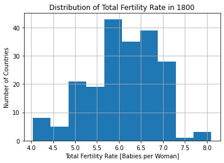

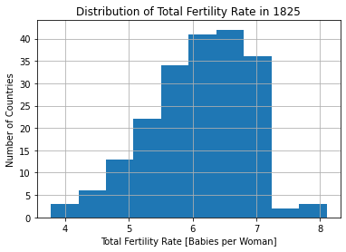

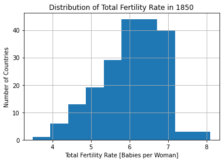

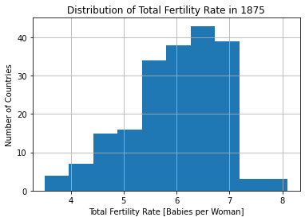

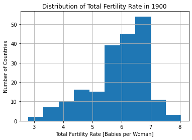

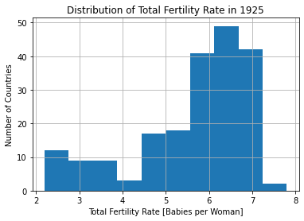

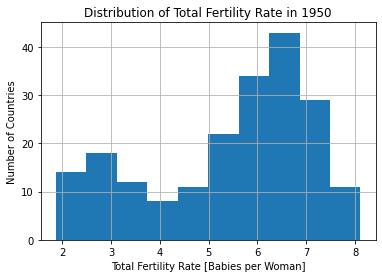

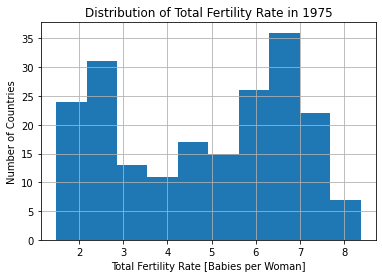

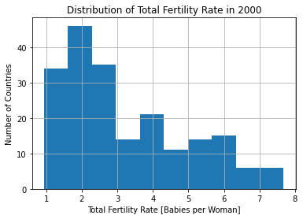

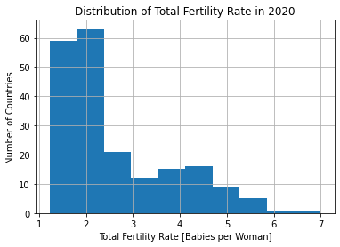

```python
# for concictency we will plot the distrbution every 25 years
# making a numpy array that holds the choosen years
_25_array = np.arange(1800, 2020, 25).astype(str)
_25_array = np.append(_25_array, '2020')

# filtering the dataset to hold the choosen years
# ploting a histogram for each of those years
for year in _25_array:
    df_tfr.hist(column = year);
    plt.title('Distribution of Total Fertility Rate in ' + year)
    plt.xlabel('Total Fertility Rate [Babies per Woman]')
    plt.ylabel('Number of Countries')
```

- Unitll 1950 the highest numbers of Total Fertility Rates were between 5.5 and 7.
- In 1975 the curve has flattened alittle bit and the highest numbers of Total Fertility Rates were between 5.5 and 7 but the numbers between 1 and 3 has raised significantly.
- In 2000 the curve has been skewed to the right with highest numbers of Total Fertility Rates between 1 and 3.
- In 2020 the curve has beem more skewed to the right with highest numbers of Total Fertility Rates between 1 and 3.

#### For the purpose of this report we will focus on analysing the trends in Continents and in five African Countries: Egypt (Nort East), Mali (North West), Kenya (South East), Angola (South West) and South Africa (South)

```python
# checking whether the choosen countries exit in all datasets
focus_countries = ['Egypt', 'Mali', 'Kenya', 'Angola', 'South Africa']
for country in focus_countries:
    for index, df in enumerate([df_tfr.index, df_cmr.index, df_erg.index]):
        print(country, 'in', index, country in df)
```

```
Egypt in 0 True
Egypt in 1 True
Egypt in 2 True
Mali in 0 True
Mali in 1 True
Mali in 2 True
Kenya in 0 True
Kenya in 1 True
Kenya in 2 True
Angola in 0 True
Angola in 1 True
Angola in 2 True
South Africa in 0 True
South Africa in 1 True
South Africa in 2 True
```

### Research Question 2 (Are there any trends in Continents Total Fertility Rates over the years?)

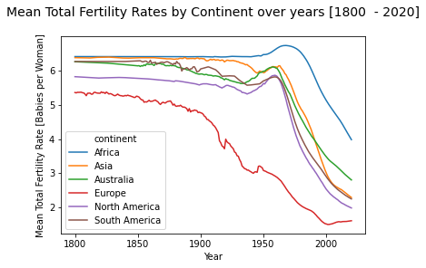

```python
# grouping total fertility rate dataset by continent
# transposing the dataset to be able to plot its columns
df_tfr.groupby('continent').mean().transpose().plot(kind='line')
plt.title('Mean Total Fertility Rates by Continent over years [1800  - 2020]\n', fontsize=14)
plt.xlabel('Year')
plt.ylabel('Mean Total Fertility Rate [Babies per Woman]')
```

- Africa had the highest mean Total Fertility Rates over the years.
- Europe had the lowest mean Total Fertility Rates over the years
- Except for Europe, the curves were quite steady untill the 1950s.
- Except for Europe, the mean Total Fertility Rate was significantly ascending between 1950 and 1960 and then the curves started descending fastly unitl 2020, afirca had the same approach with some delay.
- Europe had a descending curve from the beginning (1800) until 2000, but the descendece between 1900 and 2000 was alot faster than the descendence between 1800 and 1900.
- Europe is the only Continent that had an ascending curve (inceasing in mean total fertility rates) between 2000 and 2020.

### Research Question 3 (Are there any trends in Focusing Countries Total Fertility Rates over the years?)

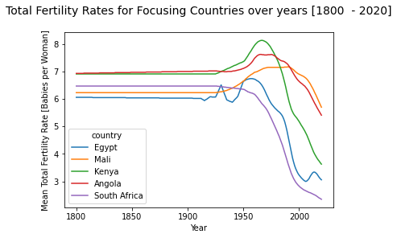

```python
df_tfr.loc[focus_countries].drop('continent', axis=1).transpose().plot(kind='line')
plt.title('Total Fertility Rates for Focusing Countries over years [1800  - 2020]\n', fontsize=14)
plt.xlabel('Year')
plt.ylabel('Mean Total Fertility Rate [Babies per Woman]')
```

- Except for South Africa, the other four countries had the same increasing in total fertility rates betweeb 1950 and 1960 and then the curves started descending fastly untill 2020.
- Egypt had an significant increase and then decrease in total fertility rates in the 1920s and 1930s.
- Egypt is the only country from the five countries that had an increases in total fertility rates between 2000 and 2010 and the the curve started to descending again.

### Research Question 4 (Which Country had the most Total Fertility Rate over the years and in what year?)

```python
df_tfr.head(1)
```

| country | continent | 1800 | 1801 | 1802 | 1803 | 1804 | 1805 | 1806 | 1807 | 1808 | ... | 2011 | 2012 | 2013 | 2014 | 2015 | 2016 | 2017 | 2018 | 2019 | 2020 |
| --- | --- | --- | --- | --- | --- | --- | --- | --- | --- | --- | --- | --- | --- | --- | --- | --- | --- | --- | --- | --- | --- |
| Aruba | North America | 5.64 | 5.64 | 5.64 | 5.64 | 5.64 | 5.64 | 5.64 | 5.64 | 5.64 | ... | 1.69 | 1.7 | 1.71 | 1.73 | 1.76 | 1.78 | 1.8 | 1.8 | 1.8 | 1.79 |

1 rows × 222 columns

```python
# searching for the maximum total fertility rate
df_tfr.drop('continent', axis=1).max(axis=1).max()
```

```
8.87
```

```python
# quering rows with the maximum total fertility rate
# making a temporary dataframe that holds only the maximum total fertility ratesdf
# dropping 'continent' column becaus its drype is string
df_temp = df_tfr.drop('continent', axis=1).max(axis=1)
df_temp.head()
```

```
country
Aruba                   5.80
Afghanistan             7.64
Angola                  7.62
Albania                 6.54
Netherlands Antilles    5.80
dtype: float64
```

```python
# quering countries that holds the maximum values
df_temp[df_temp == df_temp.max()]
```

```
country
Yemen    8.87
dtype: float64
```

```python
# quering the year when 'Yemen' had that value
df_tfr.loc['Yemen'][df_tfr.loc['Yemen'] == df_temp.max()]
```

```
1985    8.87
Name: Yemen, dtype: object
```

- Yemen had the most total fertility rate over the years with 8.87 in 1985

### Research Question 5 (Which Countries had the minimum Total Fertility Rate over the years and in what year?)

```python
# repeating the previous steps but quering the minimum value
df_tfr.drop('continent', axis=1).min(axis=1).min()
```

```
0.83
```

```python
df_temp = df_tfr.drop('continent', axis=1).min(axis=1)
df_temp.head()
```

```
country
Aruba                   1.69
Afghanistan             4.04
Angola                  5.41
Albania                 1.65
Netherlands Antilles    1.82
dtype: float64
```

```python
df_temp[df_temp == df_temp.min()]
```

```
country
Macao, China    0.83
dtype: float64
```

```python
df_tfr.loc['Macao, China'][df_tfr.loc['Macao, China'] == df_temp.min()]
```

```
2003    0.83
2004    0.83
Name: Macao, China, dtype: object
```

- Macao, China had the lowest total fertility rate over the years with 0.83 in 2003 and 2004

### Research Question 6 (At which year had each continent its most mean Total Fertility Rate?)

```python
# grouping the dataset by continents mean
# calculating the maximum mean total fertility rate over the years
df_tfr.groupby('continent').mean().max(axis=1)
```

```
continent
Africa           6.734386
Asia             6.394800
Australia        6.260000
Europe           5.379762
North America    5.864815
South America    6.301538
dtype: float64
```

```python
series_temp = df_tfr.groupby('continent').mean().max(axis=1)
```

```python
# transposing the dataset to make continents in the columns
df_temp = df_tfr.groupby('continent').mean().transpose()
```

```python
# looping over the continents (series temp index and value)
# quering rows from the transposed dataset when the rows equals to the maximum value (series_temp values)
for con in series_temp.index:
    print('Years with maximum mean Total Fertility Rate in {} are:\n{}\n'.format(con, df_temp[df_temp[con] == series_temp[con]][con]))
```

```
Years with maximum mean Total Fertility Rate in Africa are:
1968    6.734386
Name: Africa, dtype: float64

Years with maximum mean Total Fertility Rate in Asia are:
1827    6.3948
Name: Asia, dtype: float64

Years with maximum mean Total Fertility Rate in Australia are:
1800    6.26
Name: Australia, dtype: float64

Years with maximum mean Total Fertility Rate in Europe are:
1821    5.379762
Name: Europe, dtype: float64

Years with maximum mean Total Fertility Rate in North America are:
1959    5.864815
Name: North America, dtype: float64

Years with maximum mean Total Fertility Rate in South America are:
1860    6.301538
Name: South America, dtype: float64
```

### Research Question 7 (At which year had each continent its minimum mean Total Fertility Rate?)

```python
# repeating the previous steps but calculating the minimum values
df_tfr.groupby('continent').mean().min(axis=1)
```

```
continent
Africa           3.983158
Asia             2.292600
Australia        2.805385
Europe           1.504524
North America    1.986296
South America    2.250769
dtype: float64
```

```python
series_temp = df_tfr.groupby('continent').mean().min(axis=1)
```

```python
df_temp = df_tfr.groupby('continent').mean().transpose()
```

```python
for con in series_temp.index:
    print('Years with minimum mean Total Fertility Rate in {} are:\n{}\n'.format(con, df_temp[df_temp[con] == series_temp[con]][con]))
```

```
Years with minimum mean Total Fertility Rate in Africa are:
2020    3.983158
Name: Africa, dtype: float64

Years with minimum mean Total Fertility Rate in Asia are:
2020    2.2926
Name: Asia, dtype: float64

Years with minimum mean Total Fertility Rate in Australia are:
2020    2.805385
Name: Australia, dtype: float64

Years with minimum mean Total Fertility Rate in Europe are:
2002    1.504524
Name: Europe, dtype: float64

Years with minimum mean Total Fertility Rate in North America are:
2020    1.986296
Name: North America, dtype: float64

Years with minimum mean Total Fertility Rate in South America are:
2020    2.250769
Name: South America, dtype: float64
```

### Research Question 8 (At which year had each of our focusing countries its max Total Fertility Rate?)

```python
# repeating the previous steps but with focusing countries insteed of continents
df_tfr.drop('continent', axis=1).max(axis=1).head()
```

```
country
Aruba                   5.80
Afghanistan             7.64
Angola                  7.62
Albania                 6.54
Netherlands Antilles    5.80
dtype: float64
```

```python
series_temp = df_tfr.drop('continent', axis=1).max(axis=1)
```

```python
df_temp = df_tfr.drop('continent', axis=1).transpose()
```

```python
df_temp.head()
```

| country | Aruba | Afghanistan | Angola | Albania | Netherlands Antilles | United Arab Emirates | Argentina | Armenia | Antigua and Barbuda | Australia | ... | St. Vincent and the Grenadines | Venezuela | Virgin Islands (U.S.) | Vietnam | Vanuatu | Samoa | Yemen | South Africa | Zambia | Zimbabwe |
| --- | --- | --- | --- | --- | --- | --- | --- | --- | --- | --- | --- | --- | --- | --- | --- | --- | --- | --- | --- | --- | --- |
| 1800 | 5.64 | 7.0 | 6.93 | 4.6 | 5.8 | 6.94 | 6.8 | 7.80 | 5.00 | 6.50 | ... | 6.54 | 5.63 | 5.55 | 4.7 | 6.6 | 6.98 | 6.88 | 6.47 | 6.71 | 6.75 |
| 1801 | 5.64 | 7.0 | 6.93 | 4.6 | 5.8 | 6.94 | 6.8 | 7.80 | 5.00 | 6.48 | ... | 6.54 | 5.63 | 5.55 | 4.7 | 6.6 | 6.98 | 6.88 | 6.47 | 6.71 | 6.75 |
| 1802 | 5.64 | 7.0 | 6.93 | 4.6 | 5.8 | 6.94 | 6.8 | 7.81 | 4.99 | 6.46 | ... | 6.54 | 5.64 | 5.55 | 4.7 | 6.6 | 6.98 | 6.88 | 6.47 | 6.71 | 6.75 |
| 1803 | 5.64 | 7.0 | 6.93 | 4.6 | 5.8 | 6.94 | 6.8 | 7.81 | 4.99 | 6.44 | ... | 6.54 | 5.64 | 5.55 | 4.7 | 6.6 | 6.98 | 6.88 | 6.47 | 6.71 | 6.75 |
| 1804 | 5.64 | 7.0 | 6.93 | 4.6 | 5.8 | 6.94 | 6.8 | 7.81 | 4.99 | 6.42 | ... | 6.54 | 5.64 | 5.55 | 4.7 | 6.6 | 6.98 | 6.88 | 6.47 | 6.71 | 6.75 |

5 rows × 202 columns

```python
for country in focus_countries:
    print('Years with maximum Total Fertility Rate in {} are:\n{}\n'.format(country, df_temp[df_temp[country] == series_temp[country]][country]))
```

```
Years with maximum Total Fertility Rate in Egypt are:
1956    6.74
1957    6.74
1958    6.74
Name: Egypt, dtype: float64

Years with maximum Total Fertility Rate in Mali are:
1990    7.17
Name: Mali, dtype: float64

Years with maximum Total Fertility Rate in Kenya are:
1966    8.13
1967    8.13
Name: Kenya, dtype: float64

Years with maximum Total Fertility Rate in Angola are:
1965    7.62
1966    7.62
1975    7.62
Name: Angola, dtype: float64

Years with maximum Total Fertility Rate in South Africa are:
1800    6.47
1801    6.47
1802    6.47
1803    6.47
1804    6.47
        ...
1922    6.47
1923    6.47
1924    6.47
1925    6.47
1926    6.47
Name: South Africa, Length: 127, dtype: float64
```

### Research Question 9 (At which year had each of our focusing countries its minimum Total Fertility Rate?)

```python
# repeating the previous steps but calculating the minimum values
df_tfr.drop('continent', axis=1).min(axis=1).head()
```

```
country
Aruba                   1.69
Afghanistan             4.04
Angola                  5.41
Albania                 1.65
Netherlands Antilles    1.82
dtype: float64
```

```python
series_temp = df_tfr.drop('continent', axis=1).min(axis=1)
```

```python
df_temp = df_tfr.drop('continent', axis=1).transpose()
```

```python
df_temp.head()
```

| country | Aruba | Afghanistan | Angola | Albania | Netherlands Antilles | United Arab Emirates | Argentina | Armenia | Antigua and Barbuda | Australia | ... | St. Vincent and the Grenadines | Venezuela | Virgin Islands (U.S.) | Vietnam | Vanuatu | Samoa | Yemen | South Africa | Zambia | Zimbabwe |
| --- | --- | --- | --- | --- | --- | --- | --- | --- | --- | --- | --- | --- | --- | --- | --- | --- | --- | --- | --- | --- | --- |
| 1800 | 5.64 | 7.0 | 6.93 | 4.6 | 5.8 | 6.94 | 6.8 | 7.80 | 5.00 | 6.50 | ... | 6.54 | 5.63 | 5.55 | 4.7 | 6.6 | 6.98 | 6.88 | 6.47 | 6.71 | 6.75 |
| 1801 | 5.64 | 7.0 | 6.93 | 4.6 | 5.8 | 6.94 | 6.8 | 7.80 | 5.00 | 6.48 | ... | 6.54 | 5.63 | 5.55 | 4.7 | 6.6 | 6.98 | 6.88 | 6.47 | 6.71 | 6.75 |
| 1802 | 5.64 | 7.0 | 6.93 | 4.6 | 5.8 | 6.94 | 6.8 | 7.81 | 4.99 | 6.46 | ... | 6.54 | 5.64 | 5.55 | 4.7 | 6.6 | 6.98 | 6.88 | 6.47 | 6.71 | 6.75 |
| 1803 | 5.64 | 7.0 | 6.93 | 4.6 | 5.8 | 6.94 | 6.8 | 7.81 | 4.99 | 6.44 | ... | 6.54 | 5.64 | 5.55 | 4.7 | 6.6 | 6.98 | 6.88 | 6.47 | 6.71 | 6.75 |
| 1804 | 5.64 | 7.0 | 6.93 | 4.6 | 5.8 | 6.94 | 6.8 | 7.81 | 4.99 | 6.42 | ... | 6.54 | 5.64 | 5.55 | 4.7 | 6.6 | 6.98 | 6.88 | 6.47 | 6.71 | 6.75 |

5 rows × 202 columns

```python
for country in focus_countries:
    print('Years with minimum Total Fertility Rate in {} are:\n{}\n'.format(country, df_temp[df_temp[country] == series_temp[country]][country]))
```

```
Years with minimum Total Fertility Rate in Egypt are:
2006    3.0
Name: Egypt, dtype: float64

Years with minimum Total Fertility Rate in Mali are:
2020    5.7
Name: Mali, dtype: float64

Years with minimum Total Fertility Rate in Kenya are:
2020    3.63
Name: Kenya, dtype: float64

Years with minimum Total Fertility Rate in Angola are:
2020    5.41
Name: Angola, dtype: float64

Years with minimum Total Fertility Rate in South Africa are:
2020    2.35
Name: South Africa, dtype: float64
```

### Research Question 10 (What is the distribution of Child Mortality Rate over the years)

```python
df_cmr.head(1)
```

| country | continent | 1800 | 1801 | 1802 | 1803 | 1804 | 1805 | 1806 | 1807 | 1808 | ... | 2011 | 2012 | 2013 | 2014 | 2015 | 2016 | 2017 | 2018 | 2019 | 2020 |
| --- | --- | --- | --- | --- | --- | --- | --- | --- | --- | --- | --- | --- | --- | --- | --- | --- | --- | --- | --- | --- | --- |
| Afghanistan | Asia | 469.0 | 469.0 | 469.0 | 469.0 | 469.0 | 469.0 | 470.0 | 470.0 | 470.0 | ... | 84.1 | 80.5 | 77.0 | 73.5 | 70.4 | 67.5 | 64.7 | 62.3 | 60.1 | 58.1 |

1 rows × 222 columns

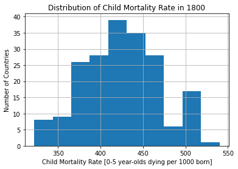

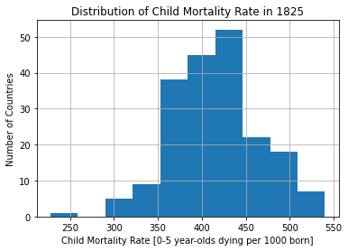

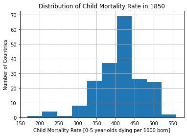

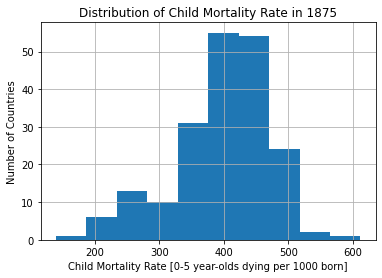

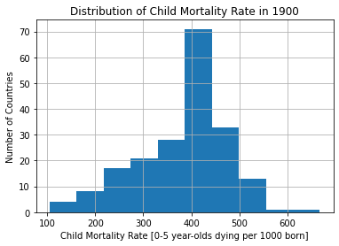

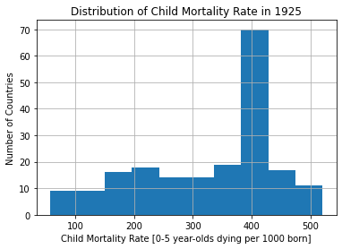

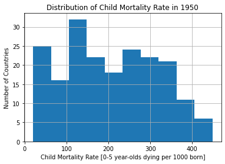

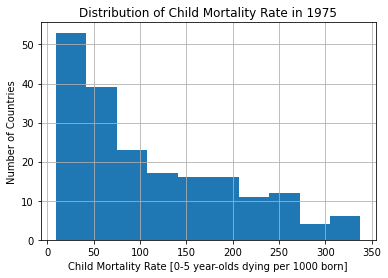

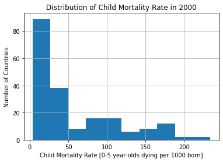

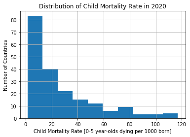

```python
for year in _25_array:
    df_cmr.hist(column=year);
    plt.title('Distribution of Child Mortality Rate in '+year)
    plt.xlabel('Child Mortality Rate [0-5 year-olds dying per 1000 born]')
    plt.ylabel('Number of Countries')
```

- In 1800 and 1825 the highest numbers of child mortality rates were between 400 and 450.
- From 1850 to 1925 the highest number of child mortality rate was about 400.
- In 1950 the curve has flattened, the hightes number of child mortality rate was about 150 and numbers above 350 were the lowest.
- In 1975 the curve has been skewed to the right and numbers between 0 and 50 were the highest.
- In 2000 the curver has been skewed to the right and numbers between 0 and 25 were the highest.
- In 2020 the curver has been skewed to the right and numbers between 0 and 10 were the highest.

### Research Question 11 (Are there any trends in Continents Child Mortality Rates over the years?)

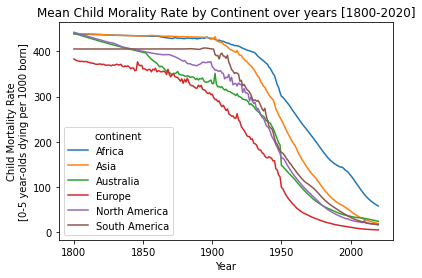

```python
df_cmr.groupby('continent').mean().transpose().plot(kind='line');
plt.title('Mean Child Morality Rate by Continent over years [1800-2020]')
plt.xlabel('Year')
plt.ylabel('Child Mortality Rate\n[0-5 year-olds dying per 1000 born]')
```

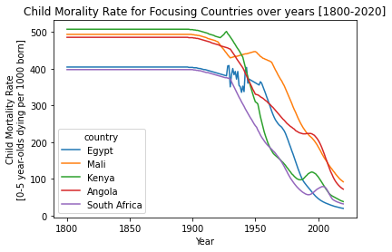

```python
df_cmr.loc[focus_countries].drop('continent', axis=1).transpose().plot(kind='line')
plt.title('Child Morality Rate for Focusing Countries over years [1800-2020]')
plt.xlabel('Year')
plt.ylabel('Child Mortality Rate\n[0-5 year-olds dying per 1000 born]')
```

### Research Question 13 (Which Country had the most Child Mortality Rate over the years and in what year?)

```python
# making a series with countries and thier maximum values
series_temp = df_cmr.drop('continent', axis=1).max(axis=1)
```

```python
series_temp.head()
```

```
country
Afghanistan             483.0
Angola                  486.0
Albania                 375.0
Andorra                 375.0
United Arab Emirates    434.0
dtype: float64
```

```python
# quering rows with maximum values
series_temp = series_temp[series_temp == series_temp.max()]
series_temp
```

```
country
Philippines    756.0
Palau          756.0
dtype: float64
```

```python
# quering rows where Philippines and Palau had thier maximum child mortality rates
df_temp = df_cmr.drop('continent', axis=1).transpose()[series_temp.index]
```

```python
df_temp.head()
```

| country | Philippines | Palau |
| --- | --- | --- |
| 1800 | 432.0 | 432.0 |
| 1801 | 432.0 | 432.0 |
| 1802 | 432.0 | 432.0 |
| 1803 | 432.0 | 432.0 |
| 1804 | 432.0 | 432.0 |

```python
df_temp['Philippines'][df_temp['Philippines'] == df_temp['Philippines'].max()]
```

```
1902    756.0
Name: Philippines, dtype: float64
```

```python
df_temp['Palau'][df_temp['Palau'] == df_temp['Palau'].max()]
```

```
1902    756.0
Name: Palau, dtype: float64
```

- The countries that has the highest child mortality rate between 1800 and 2020 were Philippines and Palau in 1902

### Research Question 14 (Which Country had the minimum Child Mortality Rate over the years and in what year?)

```python
# seaching for the lowest value in the dataset
df_cmr.drop('continent', axis=1).min(axis=1).min()
```

```
1.58
```

```python
# transposing the dataset to make countries as columns
df_temp = df_cmr.drop('continent', axis=1).transpose()
```

```python
df_temp.head()
```

| country | Afghanistan | Angola | Albania | Andorra | United Arab Emirates | Argentina | Armenia | Antigua and Barbuda | Australia | Austria | ... | Uzbekistan | St. Vincent and the Grenadines | Venezuela | Vietnam | Vanuatu | Samoa | Yemen | South Africa | Zambia | Zimbabwe |
| --- | --- | --- | --- | --- | --- | --- | --- | --- | --- | --- | --- | --- | --- | --- | --- | --- | --- | --- | --- | --- | --- |
| 1800 | 469.0 | 486.0 | 375.0 | 375.0 | 434.0 | 402.0 | 371.0 | 474.0 | 391.0 | 387.0 | ... | 381.0 | 463.0 | 415.0 | 417.0 | 426.0 | 471.0 | 540.0 | 398.0 | 410.0 | 396.0 |
| 1801 | 469.0 | 486.0 | 375.0 | 375.0 | 434.0 | 402.0 | 371.0 | 470.0 | 391.0 | 373.0 | ... | 381.0 | 461.0 | 415.0 | 417.0 | 424.0 | 468.0 | 540.0 | 398.0 | 410.0 | 396.0 |
| 1802 | 469.0 | 486.0 | 375.0 | 375.0 | 434.0 | 402.0 | 370.0 | 466.0 | 391.0 | 359.0 | ... | 381.0 | 458.0 | 415.0 | 417.0 | 421.0 | 465.0 | 540.0 | 398.0 | 410.0 | 396.0 |
| 1803 | 469.0 | 486.0 | 375.0 | 375.0 | 434.0 | 402.0 | 370.0 | 462.0 | 391.0 | 346.0 | ... | 381.0 | 456.0 | 415.0 | 417.0 | 419.0 | 461.0 | 540.0 | 398.0 | 410.0 | 396.0 |
| 1804 | 469.0 | 486.0 | 375.0 | 375.0 | 434.0 | 402.0 | 369.0 | 458.0 | 391.0 | 333.0 | ... | 381.0 | 453.0 | 415.0 | 417.0 | 417.0 | 458.0 | 540.0 | 398.0 | 410.0 | 396.0 |

5 rows × 197 columns

```python
# quering countries with the lowest values
df_temp.min()[df_temp.min() == 1.58]
```

```
country
Finland    1.58
dtype: float64
```

```python
# quering the year at which finland had its lowest value
df_temp.query('Finland == {}'.format(1.58))['Finland']
```

```
2020    1.58
Name: Finland, dtype: float64
```

- The coutry that had the lowest child mortality rate between 1800 and 2020 is Finland in 2020

### Research Question 15 (At which year had each continent its most mean Child Mortality Rate?)

```python
# grouping the dataset by continents mean values for each year
# calculating the maximum mean value for each continent
df_cmr.groupby('continent').mean().max(axis=1)
```

```
continent
Africa           439.092593
Asia             439.673469
Australia        440.142857
Europe           383.244444
North America    442.608696
South America    407.833333
dtype: float64
```

```python
series_temp = df_cmr.groupby('continent').mean().max(axis=1)
```

```python
# transposing the dataset to make continents as columns and years as rows
df_temp = df_cmr.groupby('continent').mean().transpose()
```

```python
df_temp.head()
```

| continent | Africa | Asia | Australia | Europe | North America | South America |
| --- | --- | --- | --- | --- | --- | --- |
| 1800 | 439.092593 | 439.673469 | 440.142857 | 383.244444 | 442.608696 | 405.5 |
| 1801 | 438.981481 | 439.653061 | 439.214286 | 381.488889 | 441.695652 | 405.5 |
| 1802 | 438.870370 | 439.530612 | 438.285714 | 379.822222 | 440.695652 | 405.5 |
| 1803 | 438.777778 | 439.448980 | 437.214286 | 379.022222 | 439.782609 | 405.5 |
| 1804 | 438.666667 | 439.326531 | 436.357143 | 378.377778 | 438.869565 | 405.5 |

```python
# looping over the series_temp and quering rows (years) when each continent had its maximum mean value and printing it
for con in series_temp.index:
    print('Years with maximum mean Child Mortality Rate in {} are:\n{}\n'.format(con, df_temp[df_temp[con] == series_temp[con]][con]))
```

```
Years with maximum mean Child Mortality Rate in Africa are:
1800    439.092593
Name: Africa, dtype: float64

Years with maximum mean Child Mortality Rate in Asia are:
1800    439.673469
Name: Asia, dtype: float64

Years with maximum mean Child Mortality Rate in Australia are:
1800    440.142857
Name: Australia, dtype: float64

Years with maximum mean Child Mortality Rate in Europe are:
1800    383.244444
Name: Europe, dtype: float64

Years with maximum mean Child Mortality Rate in North America are:
1800    442.608696
Name: North America, dtype: float64

Years with maximum mean Child Mortality Rate in South America are:
1895    407.833333
Name: South America, dtype: float64
```

### Research Question 16 (At which year had each continent its minimum mean Child Mortality Rate?)

```python
# repeating the previous steps but quering the minimum values
df_cmr.groupby('continent').mean().min(axis=1)
```

```
continent
Africa           57.637037
Asia             19.150816
Australia        23.895714
Europe            4.614444
North America    16.283913
South America    16.196667
dtype: float64
```

```python
series_temp = df_cmr.groupby('continent').mean().min(axis=1)
```

```python
series_temp
```

```
continent
Africa           57.637037
Asia             19.150816
Australia        23.895714
Europe            4.614444
North America    16.283913
South America    16.196667
dtype: float64
```

```python
df_temp = df_cmr.groupby('continent').mean().transpose()
```

```python
df_temp.head()
```

| continent | Africa | Asia | Australia | Europe | North America | South America |
| --- | --- | --- | --- | --- | --- | --- |
| 1800 | 439.092593 | 439.673469 | 440.142857 | 383.244444 | 442.608696 | 405.5 |
| 1801 | 438.981481 | 439.653061 | 439.214286 | 381.488889 | 441.695652 | 405.5 |
| 1802 | 438.870370 | 439.530612 | 438.285714 | 379.822222 | 440.695652 | 405.5 |
| 1803 | 438.777778 | 439.448980 | 437.214286 | 379.022222 | 439.782609 | 405.5 |
| 1804 | 438.666667 | 439.326531 | 436.357143 | 378.377778 | 438.869565 | 405.5 |

```python
for con in series_temp.index:
    print('Years with minimum mean Child Mortality Rate in {} are:\n{}\n'.format(con, df_temp[df_temp[con] == series_temp[con]][con]))
```

```
Years with minimum mean Child Mortality Rate in Africa are:
2020    57.637037
Name: Africa, dtype: float64

Years with minimum mean Child Mortality Rate in Asia are:
2020    19.150816
Name: Asia, dtype: float64

Years with minimum mean Child Mortality Rate in Australia are:
2020    23.895714
Name: Australia, dtype: float64

Years with minimum mean Child Mortality Rate in Europe are:
2020    4.614444
Name: Europe, dtype: float64

Years with minimum mean Child Mortality Rate in North America are:
2020    16.283913
Name: North America, dtype: float64

Years with minimum mean Child Mortality Rate in South America are:
2020    16.196667
Name: South America, dtype: float64
```

### Research Question 17 (At which year had each of our focusing countries its max Child Mortality Rate?)

```python
# repeating the previous steps but with focusing countries instead of continents
df_cmr.drop('continent', axis=1).max(axis=1).head()
```

```
country
Afghanistan             483.0
Angola                  486.0
Albania                 375.0
Andorra                 375.0
United Arab Emirates    434.0
dtype: float64
```

```python
series_temp = df_cmr.drop('continent', axis=1).max(axis=1)
```

```python
df_temp = df_cmr.drop('continent', axis=1).transpose()
```

```python
df_temp.head()
```

| country | Afghanistan | Angola | Albania | Andorra | United Arab Emirates | Argentina | Armenia | Antigua and Barbuda | Australia | Austria | ... | Uzbekistan | St. Vincent and the Grenadines | Venezuela | Vietnam | Vanuatu | Samoa | Yemen | South Africa | Zambia | Zimbabwe |
| --- | --- | --- | --- | --- | --- | --- | --- | --- | --- | --- | --- | --- | --- | --- | --- | --- | --- | --- | --- | --- | --- |
| 1800 | 469.0 | 486.0 | 375.0 | 375.0 | 434.0 | 402.0 | 371.0 | 474.0 | 391.0 | 387.0 | ... | 381.0 | 463.0 | 415.0 | 417.0 | 426.0 | 471.0 | 540.0 | 398.0 | 410.0 | 396.0 |
| 1801 | 469.0 | 486.0 | 375.0 | 375.0 | 434.0 | 402.0 | 371.0 | 470.0 | 391.0 | 373.0 | ... | 381.0 | 461.0 | 415.0 | 417.0 | 424.0 | 468.0 | 540.0 | 398.0 | 410.0 | 396.0 |
| 1802 | 469.0 | 486.0 | 375.0 | 375.0 | 434.0 | 402.0 | 370.0 | 466.0 | 391.0 | 359.0 | ... | 381.0 | 458.0 | 415.0 | 417.0 | 421.0 | 465.0 | 540.0 | 398.0 | 410.0 | 396.0 |
| 1803 | 469.0 | 486.0 | 375.0 | 375.0 | 434.0 | 402.0 | 370.0 | 462.0 | 391.0 | 346.0 | ... | 381.0 | 456.0 | 415.0 | 417.0 | 419.0 | 461.0 | 540.0 | 398.0 | 410.0 | 396.0 |
| 1804 | 469.0 | 486.0 | 375.0 | 375.0 | 434.0 | 402.0 | 369.0 | 458.0 | 391.0 | 333.0 | ... | 381.0 | 453.0 | 415.0 | 417.0 | 417.0 | 458.0 | 540.0 | 398.0 | 410.0 | 396.0 |

5 rows × 197 columns

```python
for coun in focus_countries:
    print('Years with maximum Child Mortality Rate in {} are:\n{}\n'.format(coun, df_temp[df_temp[coun] == series_temp[coun]][coun]))
```

```
Years with maximum Child Mortality Rate in Egypt are:
1929    409.0
Name: Egypt, dtype: float64

Years with maximum Child Mortality Rate in Mali are:
1800    494.0
1801    494.0
1802    494.0
1803    494.0
1804    494.0
        ...
1895    494.0
1896    494.0
1897    494.0
1898    494.0
1899    494.0
Name: Mali, Length: 100, dtype: float64

Years with maximum Child Mortality Rate in Kenya are:
1800    508.0
1801    508.0
1802    508.0
1803    508.0
1804    508.0
        ...
1893    508.0
1894    508.0
1895    508.0
1896    508.0
1897    508.0
Name: Kenya, Length: 98, dtype: float64

Years with maximum Child Mortality Rate in Angola are:
1800    486.0
1801    486.0
1802    486.0
1803    486.0
1804    486.0
        ...
1892    486.0
1893    486.0
1894    486.0
1895    486.0
1896    486.0
Name: Angola, Length: 97, dtype: float64

Years with maximum Child Mortality Rate in South Africa are:
1800    398.0
1801    398.0
1802    398.0
1803    398.0
1804    398.0
        ...
1896    398.0
1897    398.0
1898    398.0
1899    398.0
1900    398.0
Name: South Africa, Length: 101, dtype: float64
```

### Research Question 18 (At which year had each of our focusing countries its minimum Child Mortality Rate?)

```python
# repeating the previous steps but quering minimum values
df_cmr.drop('continent', axis=1).min(axis=1).head()
```

```
country
Afghanistan             58.10
Angola                  72.30
Albania                  8.52
Andorra                  2.85
United Arab Emirates     7.16
dtype: float64
```

```python
series_temp = df_cmr.drop('continent', axis=1).min(axis=1)
```

```python
df_temp = df_cmr.drop('continent', axis=1).transpose()
```

```python
df_temp.head()
```

| country | Afghanistan | Angola | Albania | Andorra | United Arab Emirates | Argentina | Armenia | Antigua and Barbuda | Australia | Austria | ... | Uzbekistan | St. Vincent and the Grenadines | Venezuela | Vietnam | Vanuatu | Samoa | Yemen | South Africa | Zambia | Zimbabwe |
| --- | --- | --- | --- | --- | --- | --- | --- | --- | --- | --- | --- | --- | --- | --- | --- | --- | --- | --- | --- | --- | --- |
| 1800 | 469.0 | 486.0 | 375.0 | 375.0 | 434.0 | 402.0 | 371.0 | 474.0 | 391.0 | 387.0 | ... | 381.0 | 463.0 | 415.0 | 417.0 | 426.0 | 471.0 | 540.0 | 398.0 | 410.0 | 396.0 |
| 1801 | 469.0 | 486.0 | 375.0 | 375.0 | 434.0 | 402.0 | 371.0 | 470.0 | 391.0 | 373.0 | ... | 381.0 | 461.0 | 415.0 | 417.0 | 424.0 | 468.0 | 540.0 | 398.0 | 410.0 | 396.0 |
| 1802 | 469.0 | 486.0 | 375.0 | 375.0 | 434.0 | 402.0 | 370.0 | 466.0 | 391.0 | 359.0 | ... | 381.0 | 458.0 | 415.0 | 417.0 | 421.0 | 465.0 | 540.0 | 398.0 | 410.0 | 396.0 |
| 1803 | 469.0 | 486.0 | 375.0 | 375.0 | 434.0 | 402.0 | 370.0 | 462.0 | 391.0 | 346.0 | ... | 381.0 | 456.0 | 415.0 | 417.0 | 419.0 | 461.0 | 540.0 | 398.0 | 410.0 | 396.0 |
| 1804 | 469.0 | 486.0 | 375.0 | 375.0 | 434.0 | 402.0 | 369.0 | 458.0 | 391.0 | 333.0 | ... | 381.0 | 453.0 | 415.0 | 417.0 | 417.0 | 458.0 | 540.0 | 398.0 | 410.0 | 396.0 |

5 rows × 197 columns

```python
for coun in focus_countries:
    print('Years with minimum Child Mortality Rate in {} are:\n{}\n'.format(coun, df_temp[df_temp[coun] == series_temp[coun]][coun]))
```

```
Years with minimum Child Mortality Rate in Egypt are:
2020    19.8
Name: Egypt, dtype: float64

Years with minimum Child Mortality Rate in Mali are:
2020    92.4
Name: Mali, dtype: float64

Years with minimum Child Mortality Rate in Kenya are:
2020    38.5
Name: Kenya, dtype: float64

Years with minimum Child Mortality Rate in Angola are:
2020    72.3
Name: Angola, dtype: float64

Years with minimum Child Mortality Rate in South Africa are:
2020    32.1
Name: South Africa, dtype: float64
```

### Research Question 19 (Which Country had lost the most number of children per 1000 child over the years?)

```python
df_cmr.head(1)
```

| country | continent | 1800 | 1801 | 1802 | 1803 | 1804 | 1805 | 1806 | 1807 | 1808 | ... | 2011 | 2012 | 2013 | 2014 | 2015 | 2016 | 2017 | 2018 | 2019 | 2020 |
| --- | --- | --- | --- | --- | --- | --- | --- | --- | --- | --- | --- | --- | --- | --- | --- | --- | --- | --- | --- | --- | --- |
| Afghanistan | Asia | 469.0 | 469.0 | 469.0 | 469.0 | 469.0 | 469.0 | 470.0 | 470.0 | 470.0 | ... | 84.1 | 80.5 | 77.0 | 73.5 | 70.4 | 67.5 | 64.7 | 62.3 | 60.1 | 58.1 |

1 rows × 222 columns

```python
# calculating the mean child mortality rate value betweet 1800 and 2020 for each country
series_temp = df_cmr.drop('continent', axis=1).mean(axis=1)
```

```python
series_temp.head()
```

```
country
Afghanistan             389.253846
Angola                  392.066968
Albania                 275.785566
Andorra                 253.912941
United Arab Emirates    311.844615
dtype: float64
```

```python
# quering the maximum value
series_temp[series_temp == series_temp.max()]
```

```
country
Sierra Leone    432.678733
dtype: float64
```

- Sierra Leone had lost the most number of children per 1000 child between 1800 and 2020 with a mean value about 433 child per 1000 child per year

### Research Question 20 (Which Country had lost the least children per 1000 child over the years?)

```python
# quering the minimum value
series_temp[series_temp == series_temp.min()]
```

```
country
Norway    123.498009
dtype: float64
```

- Norway had lost the lowest number of children per 1000 child between 1800 and 2020 with a mean value about 123 child per 1000 child per year.

### Research Question 21 (Which Continent had lost the most number of children per 1000 child over the years?)

```python
# repeating previous steps but for each continent
df_cmr.head(1)
```

| country | continent | 1800 | 1801 | 1802 | 1803 | 1804 | 1805 | 1806 | 1807 | 1808 | ... | 2011 | 2012 | 2013 | 2014 | 2015 | 2016 | 2017 | 2018 | 2019 | 2020 |
| --- | --- | --- | --- | --- | --- | --- | --- | --- | --- | --- | --- | --- | --- | --- | --- | --- | --- | --- | --- | --- | --- |
| Afghanistan | Asia | 469.0 | 469.0 | 469.0 | 469.0 | 469.0 | 469.0 | 470.0 | 470.0 | 470.0 | ... | 84.1 | 80.5 | 77.0 | 73.5 | 70.4 | 67.5 | 64.7 | 62.3 | 60.1 | 58.1 |

1 rows × 222 columns

```python
series_temp = df_cmr.groupby('continent').mean().mean(axis=1)
```

```python
series_temp
```

```
continent
Africa           340.520706
Asia             311.414807
Australia        259.576642
Europe           219.731535
North America    269.021186
South America    278.259800
dtype: float64
```

```python
# quering the maximum value
series_temp[series_temp == series_temp.max()]
```

```
continent
Africa    340.520706
dtype: float64
```

- Africa had lost the most number of children per 1000 child between 1800 and 2020 with a mean value about 341 child per 1000 child per year

### Research Question 22 (Which Continent had lost the least number of children per 1000 child over the years?)

```python
# quering the minimum value
series_temp[series_temp == series_temp.min()]
```

```
continent
Europe    219.731535
dtype: float64
```

- Europe had lost the lowest number of children per 1000 child between 1800 and 2020 with a mean value about 220 child per 1000 child per year.

### Research Question 23 (Which of our focusing countries had lost the most number of children per 1000 child over the years?)

```python
# repeating the previous steps but for our focusing countries
df_cmr.head(1)
```

| country | continent | 1800 | 1801 | 1802 | 1803 | 1804 | 1805 | 1806 | 1807 | 1808 | ... | 2011 | 2012 | 2013 | 2014 | 2015 | 2016 | 2017 | 2018 | 2019 | 2020 |
| --- | --- | --- | --- | --- | --- | --- | --- | --- | --- | --- | --- | --- | --- | --- | --- | --- | --- | --- | --- | --- | --- |
| Afghanistan | Asia | 469.0 | 469.0 | 469.0 | 469.0 | 469.0 | 469.0 | 470.0 | 470.0 | 470.0 | ... | 84.1 | 80.5 | 77.0 | 73.5 | 70.4 | 67.5 | 64.7 | 62.3 | 60.1 | 58.1 |

1 rows × 222 columns

```python
series_temp = df_cmr.loc[focus_countries].drop('continent', axis=1).mean(axis=1)
```

```python
series_temp
```

```
country
Egypt           320.137104
Mali            415.430769
Kenya           376.714480
Angola          392.066968
South Africa    295.396833
dtype: float64
```

```python
# quering the maximum value
series_temp[series_temp == series_temp.max()]
```

```
country
Mali    415.430769
dtype: float64
```

- In our focusing coutries, Mali had lost the highest number of children per 1000 child between 1800 and 2020 with a mean value about 415 child per 1000 child per year.

### Research Question 24 (Which of our focusing countries had lost the least number of children per 1000 child over the years?)

```python
# quering the minimum mean value
series_temp[series_temp == series_temp.min()]
```

```
country
South Africa    295.396833
dtype: float64
```

- In our focusing countries, South had lost the lowest number of children per 1000 child between 1800 and 2020 with a mean value about 295 child per 1000 child per year.